# Introduction to Regression with statsmodels in Python

### Transforming variables

```python
# checking number of unique fish species in the Fish dataset
fish["species"].value_counts()
```

```
Perch    56
Bream    35
Roach    20
Pike     17
Name: species, dtype: int64
```

```python
# extract "perch" from Fish dataset
perch = fish[fish["species"]=="Perch"]
print(perch)
```

```
    species  mass_g  length_cm
55    Perch     5.9        7.5
56    Perch    32.0       12.5
57    Perch    40.0       13.8
58    Perch    51.5       15.0
59    Perch    70.0       15.7
60    Perch   100.0       16.2
61    Perch    78.0       16.8
62    Perch    80.0       17.2
63    Perch    85.0       17.8
64    Perch    85.0       18.2
65    Perch   110.0       19.0
66    Perch   115.0       19.0
67    Perch   125.0       19.0
68    Perch   130.0       19.3
```

[output cut: 42 more lines]

```python
print(perch.info())
#print(fish[fish["species"]=="perch"].info())
```

```
<class 'pandas.core.frame.DataFrame'>
Int64Index: 56 entries, 55 to 110
Data columns (total 3 columns):
 #   Column     Non-Null Count  Dtype
---  ------     --------------  -----
 0   species    56 non-null     object
 1   mass_g     56 non-null     float64
 2   length_cm  56 non-null     float64
dtypes: float64(2), object(1)
memory usage: 1.8+ KB
None
```

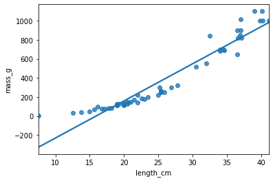

```python
# plot regression line
sns.regplot(x="length_cm", y="mass_g", data=perch, ci=None)
plt.show()
```

This is not linear. Let's try transforming the length into its cubed value.

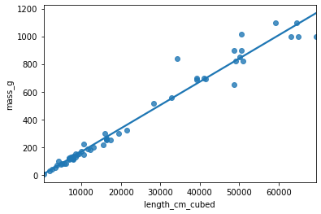

```python
# Plotting mass vs. length cubed
perch["length_cm_cubed"] = perch["length_cm"] ** 3

sns.regplot(x="length_cm_cubed", y="mass_g", data=perch, ci=None)

plt.show()
```

```python
# Modeling mass vs. length cubed
mdl_perch = ols("mass_g ~ length_cm_cubed", data=perch).fit()
mdl_perch.params
```

```
Intercept         -0.117478
length_cm_cubed    0.016796
dtype: float64
```

```python
## Predicting mass vs. length cubed

# generate data for prediction
explanatory_data = pd.DataFrame({"length_cm_cubed": np.arange(10, 41, 5) ** 3,
                                "length_cm": np.arange(10, 41, 5)})

# add predicted values to dataframe
prediction_data = explanatory_data.assign(mass_g = mdl_perch.predict(explanatory_data))

print(prediction_data)
```

```
   length_cm_cubed  length_cm       mass_g
0             1000         10    16.678135
1             3375         15    56.567717
2             8000         20   134.247429
3            15625         25   262.313982
4            27000         30   453.364084
5            42875         35   719.994447
6            64000         40  1074.801781
```

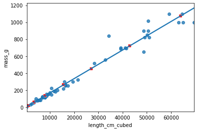

```python
# Plotting mass vs. length cubed
fig = plt.figure()

sns.regplot(x="length_cm_cubed", y="mass_g", data=perch, ci=None)

sns.scatterplot(x="length_cm_cubed", y="mass_g", data=prediction_data, color="red", marker="s")

plt.show()
```

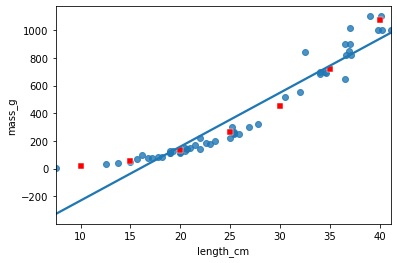

```python
# Plotting mass vs. length
fig = plt.figure()

sns.regplot(x="length_cm", y="mass_g", data=perch, ci=None)

sns.scatterplot(x="length_cm", y="mass_g", data=prediction_data, color="red", marker="s")

plt.show()
```

```python
## Another example, with Facebook advertising dataset
fb = pd.read_csv("ad_conversion.csv")
fb.head()
```

|  | spent_usd | n_impressions | n_clicks |
| --- | --- | --- | --- |
| 0 | 1.43 | 7350 | 1 |
| 1 | 1.82 | 17861 | 2 |
| 2 | 1.25 | 4259 | 1 |
| 3 | 1.29 | 4133 | 1 |
| 4 | 4.77 | 15615 | 3 |

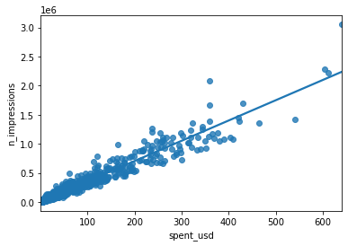

```python
# Plotting advertising data
sns.regplot(x="spent_usd", y="n_impressions", data=fb, ci=None)
plt.show()
```

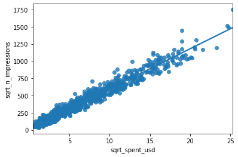

```python
# Trying square root vs square root transformation
fb["sqrt_spent_usd"] = np.sqrt(fb["spent_usd"])

fb["sqrt_n_impressions"] = np.sqrt(fb["n_impressions"])

sns.regplot(x="sqrt_spent_usd", y="sqrt_n_impressions", data=fb, ci=None)

plt.show()
```

```python
# Model and prediction
mdl_ad = ols("sqrt_n_impressions ~ sqrt_spent_usd", data=fb).fit()

explanatory_data = pd.DataFrame({"sqrt_spent_usd": np.sqrt(np.arange(0, 601, 100)),
                                "spent_usd": np.arange(0, 601, 100)})

prediction_data = explanatory_data.assign(sqrt_n_impressions = mdl_ad.predict(explanatory_data),
                                         n_impressions = mdl_ad.predict(explanatory_data) ** 2)

print(prediction_data)
```

```
   sqrt_spent_usd  spent_usd  sqrt_n_impressions  n_impressions
0        0.000000          0           15.319713   2.346936e+02
1       10.000000        100          597.736582   3.572890e+05
2       14.142136        200          838.981547   7.038900e+05
3       17.320508        300         1024.095320   1.048771e+06
4       20.000000        400         1180.153450   1.392762e+06
5       22.360680        500         1317.643422   1.736184e+06
6       24.494897        600         1441.943858   2.079202e+06
```

### Chapter 3: Quantifying model fit

```python
mdl_bream = ols("mass_g ~ length_cm", data=bream).fit()
print(mdl_bream.summary())
```

```
                            OLS Regression Results
==============================================================================
Dep. Variable:                 mass_g   R-squared:                       0.878
Model:                            OLS   Adj. R-squared:                  0.874
Method:                 Least Squares   F-statistic:                     237.6
Date:                Wed, 10 Mar 2021   Prob (F-statistic):           1.22e-16
Time:                        20:37:55   Log-Likelihood:                -199.35
No. Observations:                  35   AIC:                             402.7
Df Residuals:                      33   BIC:                             405.8
Df Model:                           1
Covariance Type:            nonrobust
==============================================================================
                 coef    std err          t      P>|t|      [0.025      0.975]
------------------------------------------------------------------------------
Intercept  -1035.3476    107.973     -9.589      0.000   -1255.020    -815.676
length_cm     54.5500      3.539     15.415      0.000      47.350      61.750
==============================================================================
Omnibus:                        7.314   Durbin-Watson:                   1.478
Prob(Omnibus):                  0.026   Jarque-Bera (JB):               10.857
Skew:                          -0.252   Prob(JB):                      0.00439
Kurtosis:                       5.682   Cond. No.                         263.
==============================================================================

Notes:
[1] Standard Errors assume that the covariance matrix of the errors is correctly specified.
```

```python
# get ".rsquared attribute" as a float
print(mdl_bream.rsquared)
```

```
0.8780627095147174
```

```python
# Given the simple linear regression, r-squared is just the squared value of the correlation between response and explanatory variables
coeff_determination = bream["length_cm"].corr(bream["mass_g"]) ** 2
print(coeff_determination)
```

```
0.8780627095147171
```

```python
# Residual standard error (RSE)
## this is a measure of the typical size of the residuals
```

```python
# Mean square error (MSE)
## MSE = RSE ** 2
mse = mdl_bream.mse_resid
print("MSE: ", mse)
```

```
MSE:  5498.555084973521
```

```python
rse = np.sqrt(mse)
print("RSE: ", rse)
```

```
RSE:  74.15224261594197
```

```python
# Let's calculate the RSE ourselves
# we take the residuals squared

## compute square residuals
residuals_sq = mdl_bream.resid ** 2
print("residuals sq: \n", residuals_sq)
```

```
residuals sq:
 0       138.957118
1       260.758635
2      5126.992578
3      1318.919660
4       390.974309
5       547.938023
6      5388.745625
7      6437.159178
8       409.330131
9       373.528738
10     1511.024102
11      914.269381
12     2709.918769
13    54698.391492
```

[output cut: 22 more lines]

```python
# compute sum of square residuals
resid_sum_of_sq = sum(residuals_sq)

# compute degree of freedom
## it's the number of observations minus the number of model coefficients
deg_freedom = len(bream.index) - 2

# print the degree of freedom
print(f"Degree of freedom: {deg_freedom}")

# compute RSE
rse = np.sqrt(resid_sum_of_sq / deg_freedom)

# print RSE
print(f"RSE: {rse}")
```

```
Degree of freedom: 33
RSE: 74.15224261594197
```

```python
# Root-mean-sqare error (RMSE)
## here we don't subtract degrees of freedom

n_obs = len(bream.index)
rmse = np.sqrt(resid_sum_of_sq / n_obs)

# print RMSE
print(f"RMSE: {rmse}")
```

```
RMSE: 72.00244396727619
```

#### Visualizing model fit

When a model has good fit, we expect it to have its errors normally distributed, and with mean zero:

- Scatter plot with trend line
- Residuals vs. fitted plot
- Q-Q plot (show's whether or not residuals follow a normal distribution)
- Scale-location plot

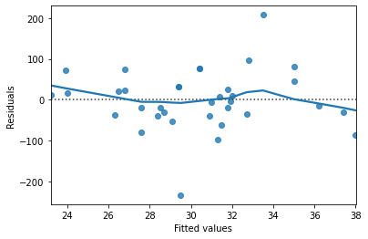

```python
# Create residual plot for the "bream" model
## If option "lowess" is set to "True", statsmodels estimates a nonparametric lowess model (locally weighted linear regression)
## see: https://seaborn.pydata.org/generated/seaborn.lmplot.html

sns.residplot(x="length_cm", y="mass_g", data=bream, lowess=True)
plt.xlabel("Fitted values")
plt.ylabel("Residuals")
plt.show()
```

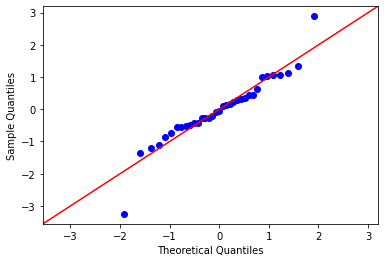

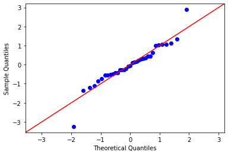

```python
# Drawing a Q-Q plot of residuals

from statsmodels.api import qqplot

qqplot(data=mdl_bream.resid, fit=True, line="45")
```

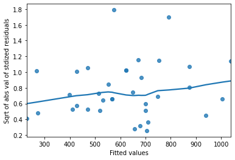

```python
# Drawing a Scale-location plot

# normalize residuals from the model
model_norm_residuals_bream = mdl_bream.get_influence().resid_studentized_internal

# standardize residuals
# take square roots of absolute values of the residuals
model_norm_residuals_abs_sqrt_bream = np.sqrt(np.abs(model_norm_residuals_bream))

# plot the graph
sns.regplot(x=mdl_bream.fittedvalues, y=model_norm_residuals_abs_sqrt_bream, ci=None, lowess=True)
plt.xlabel("Fitted values")
plt.ylabel("Sqrt of abs val of stdized residuals")
plt.show()
```

#### Outliers, leverage, and influence

```python
# extract "Roach" dataset from fish dataset
roach = fish[fish['species'] == "Roach"]
print(roach.head())
```

```
   species  mass_g  length_cm
35   Roach    40.0       12.9
36   Roach    69.0       16.5
37   Roach    78.0       17.5
38   Roach    87.0       18.2
39   Roach   120.0       18.6
```

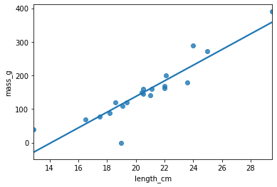

```python
# Which points are outliers?

sns.regplot(x="length_cm", y="mass_g", data=roach, ci=None)
plt.show()
```

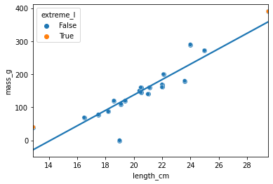

```python
# Extreme explanatory values
roach["extreme_l"] = ((roach["length_cm"] < 15) | (roach["length_cm"] > 26))

fig = plt.figure()
sns.regplot(x="length_cm", y="mass_g", data=roach, ci=None)

sns.scatterplot(x="length_cm", y="mass_g", data=roach, hue="extreme_l")
# "hue" option: Grouping variable that will produce points with different colors. Can be either categorical or numeric, although color mapping will behave differently in latter case.
plt.show()
```

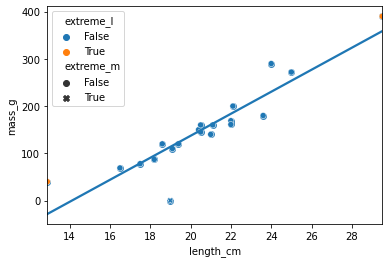

```python
# Response values away from the regression line
roach["extreme_m"] = (roach["mass_g"] < 1)

fig = plt.figure()
sns.regplot(x="length_cm", y="mass_g", data=roach, ci=None)

sns.scatterplot(x="length_cm", y="mass_g", data=roach, hue="extreme_l", style="extreme_m")
# option "style": Grouping variable that will produce points with different markers. Can have a numeric dtype but will always be treated as categorical.
# see: https://seaborn.pydata.org/generated/seaborn.scatterplot.html
plt.show()
```

### **Leverage and influence**:

- **Leverage**: is a measure of how unusual or extreme the explanatory variable is for each observation. Very roughly, high leverage means that the explanatory variable has values that are different from other points in the dataset. In the case of simple linear regression, where there is only one explanatory value, this typically means values with a very high or very low explanatory value.
- **Influence**: measures how much a model would change if each observation was left out of the model calculations, one at a time. That is, it measures how different the prediction line would look if you would run a linear regression on all data points except that point, compared to running a linear regression on the whole dataset.

Armand's note: __Leverage__ has to do with the explanatory variables, while __influence__ deals with the response variable.

```python
# Obtaining "Leverage" for the roach model

# fit an OLS model
mdl_roach = ols("mass_g ~ length_cm", data=roach).fit()

# use the .get_influence() .summary_frame() methods
summary_roach = mdl_roach.get_influence().summary_frame()

# the leverage is available in the "hat" matrix
roach["leverage"] = summary_roach["hat_diag"]

# print the roach dataset, with the "leverage" column
print(roach.head())
```

```
   species  mass_g  length_cm  extreme_l  extreme_m  leverage
35   Roach    40.0       12.9       True      False  0.313729
36   Roach    69.0       16.5      False      False  0.125538
37   Roach    78.0       17.5      False      False  0.093487
38   Roach    87.0       18.2      False      False  0.076283
39   Roach   120.0       18.6      False      False  0.068387
```

```python
# print again, but removing the 'extreme_l' and 'extreme_m' columns
print(roach.drop(['extreme_l', 'extreme_m'], axis=1).head())
```

```
   species  mass_g  length_cm  leverage
35   Roach    40.0       12.9  0.313729
36   Roach    69.0       16.5  0.125538
37   Roach    78.0       17.5  0.093487
38   Roach    87.0       18.2  0.076283
39   Roach   120.0       18.6  0.068387
```

```python
# now let's obtain the influence.
# Cook's distance is the most common measure of influence.
# Cook's distance calculates influence based on the residual size and the leverage of the point
# Cook's distance is already stored in the regression's summary frame as "cooks_d"

roach["cooks_dist"] = summary_roach["cooks_d"]
print(roach.head())
```

```
   species  mass_g  length_cm  extreme_l  extreme_m  leverage  cooks_dist
35   Roach    40.0       12.9       True      False  0.313729    1.074015
36   Roach    69.0       16.5      False      False  0.125538    0.010429
37   Roach    78.0       17.5      False      False  0.093487    0.000020
38   Roach    87.0       18.2      False      False  0.076283    0.001980
39   Roach   120.0       18.6      False      False  0.068387    0.006610
```

```python
# We can find the most influential roaches in the dataset, by arranging the rows by descending cook's distance values
print(roach.sort_values("cooks_dist", ascending = False))
```

```
   species  mass_g  length_cm  extreme_l  extreme_m  leverage  cooks_dist
35   Roach    40.0       12.9       True      False  0.313729    1.074015
54   Roach   390.0       29.5       True      False  0.394740    0.365782
40   Roach     0.0       19.0      False       True  0.061897    0.311852
52   Roach   290.0       24.0      False      False  0.099488    0.150064
51   Roach   180.0       23.6      False      False  0.088391    0.061209
53   Roach   272.0       25.0      False      False  0.133386    0.020615
49   Roach   161.0       22.0      False      False  0.058072    0.011516
36   Roach    69.0       16.5      False      False  0.125538    0.010429
46   Roach   140.0       21.0      False      False  0.050554    0.007950
39   Roach   120.0       18.6      False      False  0.068387    0.006610
48   Roach   169.0       22.0      False      False  0.058072    0.004817
50   Roach   200.0       22.1      False      False  0.059308    0.004519
45   Roach   160.0       20.5      False      False  0.050092    0.002445
38   Roach    87.0       18.2      False      False  0.076283    0.001980
41   Roach   110.0       19.1      False      False  0.060495    0.000853
43   Roach   150.0       20.4      False      False  0.050264    0.000257
44   Roach   145.0       20.5      False      False  0.050092    0.000256
42   Roach   120.0       19.4      False      False  0.056815    0.000199
47   Roach   160.0       21.1      False      False  0.050910    0.000137
37   Roach    78.0       17.5      False      False  0.093487    0.000020
```

At the top, we see how the largest values of influence (i.e., the Cook's distance) are associated with:

- really short roaches
- really long roaches
- roaches with zero mass

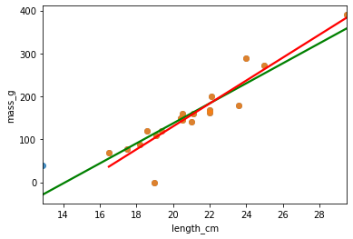

```python
# To see how influence works
# let's remove the most influential roach

# filter out the roach with 12.9 cm in length
roach_not_short = roach[roach["length_cm"] != 12.9]

# create new regression plots
sns.regplot(x="length_cm", y="mass_g", data=roach, ci=None, line_kws={"color": "green"})

sns.regplot(x="length_cm", y="mass_g", data=roach_not_short, ci=None, line_kws={"color": "red"})

plt.show()
```

## Chapter 4: Why you need logistic regression

```python
# load the "churn" dataset
churn = pd.read_csv("churn.csv")
churn
# Note: "has_churned" is the response variable. The other two (explanatory variables) have been standardized, reason why they have negative values.
```

|  | has_churned | time_since_first_purchase | time_since_last_purchase |
| --- | --- | --- | --- |
| 0 | 0 | -1.089221 | -0.721322 |
| 1 | 0 | 1.182983 | 3.634435 |
| 2 | 0 | -0.846156 | -0.427582 |
| 3 | 0 | 0.086942 | -0.535672 |
| 4 | 0 | -1.166642 | -0.672640 |
| ... | ... | ... | ... |
| 395 | 1 | 1.077655 | 0.878567 |
| 396 | 1 | -1.273770 | -0.869016 |
| 397 | 1 | -0.426195 | 0.684666 |
| 398 | 1 | 0.818836 | 1.428091 |
| 399 | 1 | 0.691452 | 1.346405 |

400 rows × 3 columns

```python
# show summary statistics of the "churn" data
churn.describe().T
```

|  | count | mean | std | min | 25% | 50% | 75% | max |
| --- | --- | --- | --- | --- | --- | --- | --- | --- |
| has_churned | 400.0 | 0.500000 | 0.500626 | 0.000000 | 0.000000 | 0.500000 | 1.000000 | 1.000000 |
| time_since_first_purchase | 400.0 | -0.034370 | 0.952936 | -1.273770 | -0.828377 | -0.152072 | 0.544826 | 3.738312 |
| time_since_last_purchase | 400.0 | 0.144549 | 1.103133 | -0.870666 | -0.645824 | -0.265036 | 0.571214 | 5.928242 |

```python
# let's first try creating a linear model f "Churn vs. Recency"
mdl_churn_vs_recency_lm = ols("has_churned ~ time_since_last_purchase", data=churn).fit()
print(mdl_churn_vs_recency_lm.params)
```

```
Intercept                   0.490780
time_since_last_purchase    0.063783
dtype: float64
```

```python
# let's retrieve the intercept and slopes from the lenear model
# we'll use these values for plotting
intercept, slope = mdl_churn_vs_recency_lm.params
```

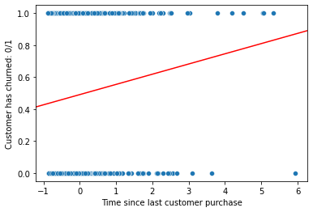

```python
# let's visualize the linear model, using a scatterplot
sns.scatterplot(x="time_since_last_purchase", y="has_churned", data=churn)

# let's use "plt.axline()" rather than "sns.regline()", so the line isn't limited to the extent of the data.
plt.axline(xy1=(0, intercept), slope=slope, color="red")

plt.xlabel("Time since last customer purchase")
plt.ylabel("Customer has churned: 0/1")
plt.show()
```

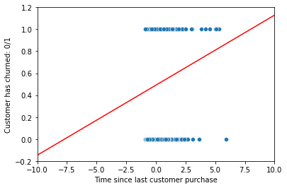

```python
# let's zoom out, to take a closer look at the plot
# we'll augment the x and y axes values

sns.scatterplot(x="time_since_last_purchase", y="has_churned", data=churn)

# let's use "plt.axline()" rather than "sns.regline()", so the line isn't limited to the extent of the data.
plt.axline(xy1=(0, intercept), slope=slope, color="red")

# augment the x and y axes values on the plot
plt.xlim(-10,10)
plt.ylim(-0.2,1.2)

plt.xlabel("Time since last customer purchase")
plt.ylabel("Customer has churned: 0/1")
plt.show()
```

**Let's run a Logistic Regression model**

```python
# import the ".logit()" module from Statsmodels
from statsmodels.formula.api import logit

# fit a logistic regression model on the churn dataset
mdl_churn_vs_recency_logit = logit("has_churned ~ time_since_last_purchase", data=churn).fit()

# print model parameters
print(mdl_churn_vs_recency_logit.params)
```

```
Optimization terminated successfully.
         Current function value: 0.683000
         Iterations 4
Intercept                  -0.035019
time_since_last_purchase    0.269215
dtype: float64
```

```python
# Now let's print the model summary table
print(mdl_churn_vs_recency_logit.summary())
```

```
                           Logit Regression Results
==============================================================================
Dep. Variable:            has_churned   No. Observations:                  400
Model:                          Logit   Df Residuals:                      398
Method:                           MLE   Df Model:                            1
Date:                Thu, 11 Mar 2021   Pseudo R-squ.:                 0.01464
Time:                        13:03:49   Log-Likelihood:                -273.20
converged:                       True   LL-Null:                       -277.26
Covariance Type:            nonrobust   LLR p-value:                  0.004384
============================================================================================
                               coef    std err          z      P>|z|      [0.025      0.975]
--------------------------------------------------------------------------------------------
Intercept                   -0.0350      0.102     -0.345      0.730      -0.234       0.164
time_since_last_purchase     0.2692      0.098      2.744      0.006       0.077       0.462
============================================================================================
```

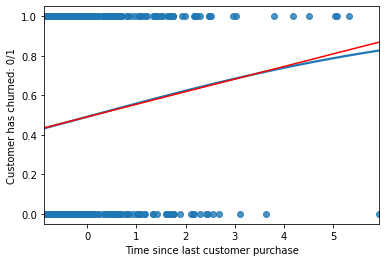

```python
# Let's visualize the logistic model, using "sns.regplot()"
sns.regplot(x="time_since_last_purchase", y="has_churned", data=churn, ci=None, logistic=True)

plt.axline(xy1=(0, intercept), slope=slope, color="red")

plt.xlabel("Time since last customer purchase")
plt.ylabel("Customer has churned: 0/1")
plt.show()
```

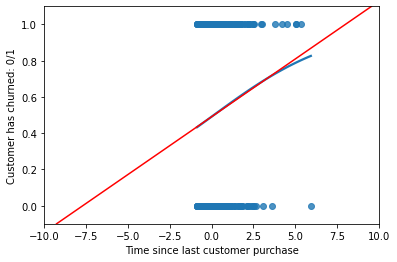

```python
# let's zoom out to make sure predicted values from the logistic regression are always within 0-1

sns.regplot(x="time_since_last_purchase", y="has_churned", data=churn, ci=None, logistic=True)

plt.axline(xy1=(0, intercept), slope=slope, color="red")

# augment the x and y axes values on the plot
plt.xlim(-10,10)
plt.ylim(-0.1,1.1)

plt.xlabel("Time since last customer purchase")
plt.ylabel("Customer has churned: 0/1")
plt.show()
```

Conclusion: Customers who recently boughts things are less likely to churn (and vice-versa)!

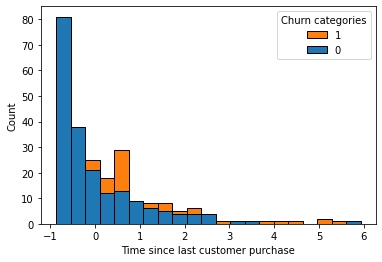

```python
# Exploring the explanatory variables

# Create the histograms of time_since_last_purchase split by has_churned
sns.histplot(x="time_since_last_purchase", hue="has_churned", data=churn, alpha=1)

# change label of x-axis
plt.xlabel("Time since last customer purchase")

# change legend
plt.legend('10', title="Churn categories", loc='upper right')

# Show the plot
plt.show()
```

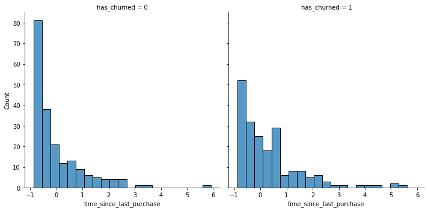

```python
# creating a distribution plot instead:
# Create the histograms of time_since_last_purchase: split by "has_churned"
sns.displot(data=churn,
            x="time_since_last_purchase",
            col="has_churned")

# change label of x-axis
plt.xlabel("Time since last customer purchase")

# Show the plot
plt.show()
```

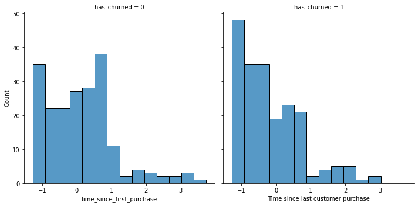

```python
# same as above, by using "time_since_first_purchase": split by "has_churned"
sns.displot(data=churn,
            x="time_since_first_purchase",
            col="has_churned")

# change label of x-axis
plt.xlabel("Time since last customer purchase")

# Show the plot
plt.show()
```

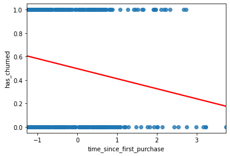

```python
# Draw a linear regression trend line and a scatter plot of time_since_first_purchase vs. has_churned
sns.regplot(x="time_since_first_purchase", y="has_churned", data=churn, ci=None,
            line_kws={"color": "red"})

# Show the plot
plt.show()
```